# Data Cleaning

# Sentiment Analysis for Comments for Teacher

```python
# combining all comment columns for teachers
All_Comments = ['Comments_Prof_Seema','Comments_Mrs_Sonam','Comments_Mrs_Anita','Comments_Prof_Ashwini','Comments_Mrs_Sakshi',
               'Comments_Mr_Pradosh','Comments_Ms_Maitri','Comments_Mrs_Priya','Comments_Ms_Abha','Comments_Ms_Rupali',
                'Comments_Mrs_Vaishali'
               ]

# Replace missing values with empty strings
for comment in All_Comments:
    df[comment] = df[comment].fillna("")

for c in All_Comments:
    df[c].isnull()
```

```python
#Define Cleaning Function
```

```python
def clean_text(text):
    text = text.lower()  # lowercase
    text = re.sub(r'[^a-z\s]', '', text)  # remove punctuation/numbers
    text = re.sub(r'\s+', ' ', text)  # remove extra spaces
    return text
```

```python
#Define Sentiment Function
```

```python
def get_sentiment(text):
    if text.strip() == "":
        return "Neutral"
    polarity = TextBlob(text).sentiment.polarity
    if polarity > 0.1:
        return "Positive"
    elif polarity < -0.1:
        return "Negative"
    else:
        return "Neutral"
```

```python
#Loop Through All Teachers and Analyze
```

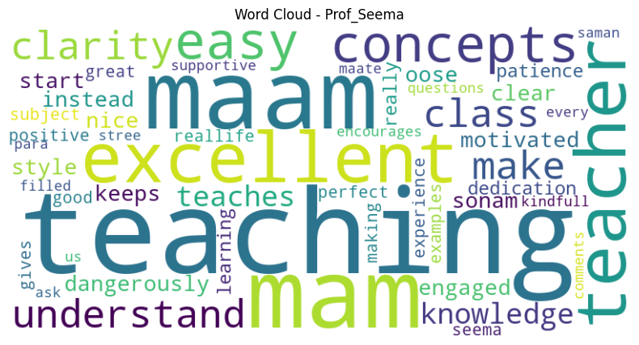

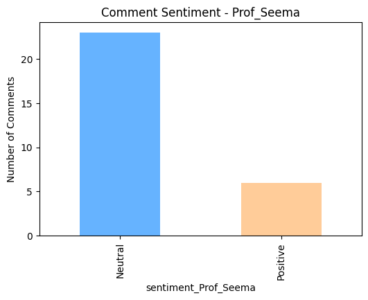

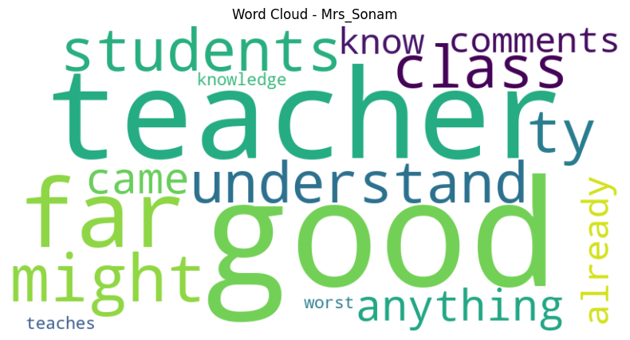

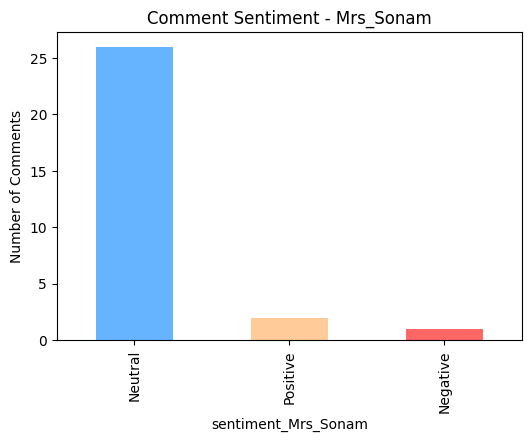

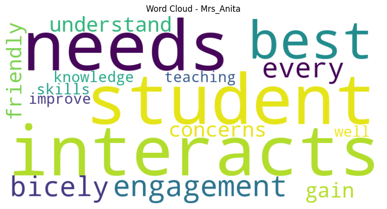

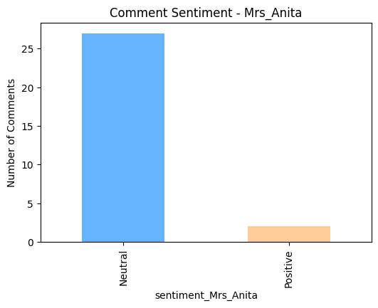

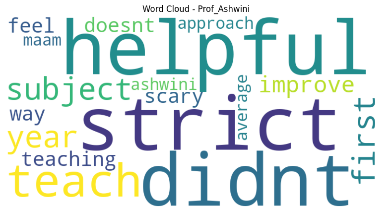

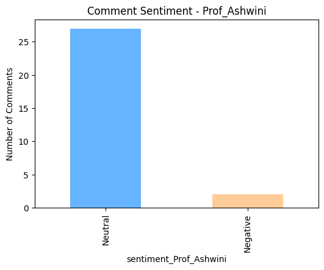

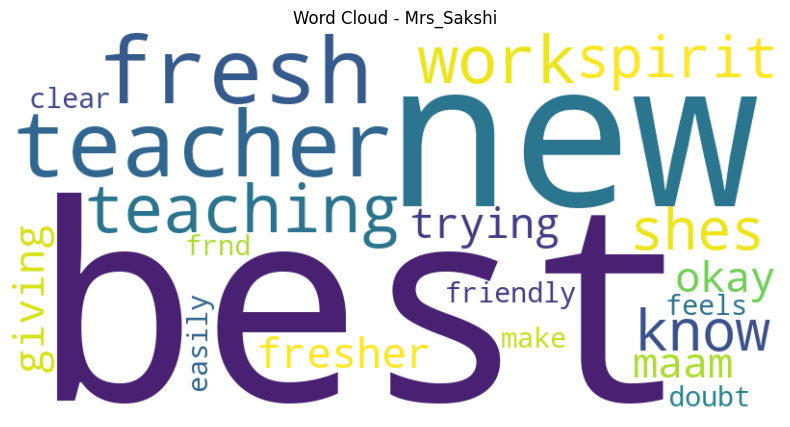

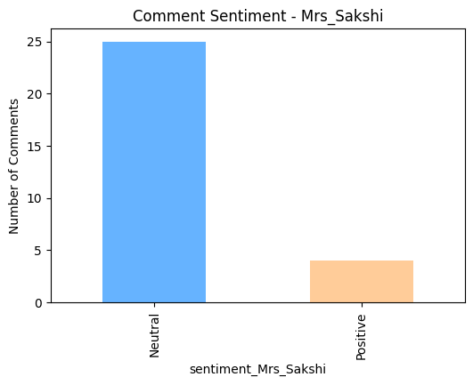

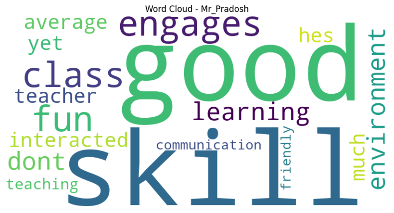

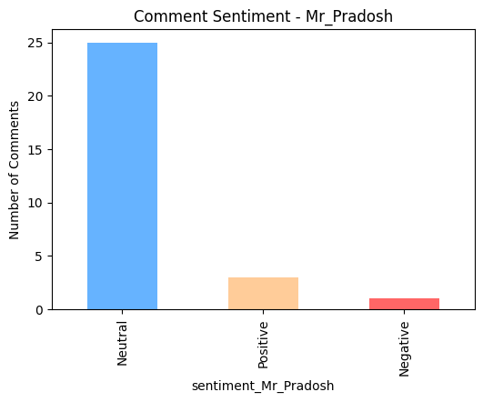

[10 more figures not shown]

```python
for col in All_Comments:
    teacher_name = col.replace("Comments_", "")

    # Clean comments
    df[f'clean_{teacher_name}'] = df[col].apply(clean_text)

    # Sentiment analysis
    df[f'sentiment_{teacher_name}'] = df[col].apply(get_sentiment)

    # Word Cloud
    all_comments = " ".join(df[f'clean_{teacher_name}'])
    wordcloud = WordCloud(width=800, height=400, background_color='white').generate(all_comments)

    plt.figure(figsize=(10,5))
    plt.imshow(wordcloud, interpolation='bilinear')
    plt.axis('off')
    plt.title(f"Word Cloud - {teacher_name}")
    plt.show()

    # Sentiment counts bar chart
    sentiment_counts = df[f'sentiment_{teacher_name}'].value_counts()
    plt.figure(figsize=(6,4))
    sentiment_counts.plot(kind='bar', color=['#66b3ff','#ffcc99','#ff6666'])
    plt.title(f"Comment Sentiment - {teacher_name}")
    plt.ylabel("Number of Comments")
    plt.show()
```

# Student Feedback Analysis – Key Insights

### 1. Teacher Performance

- Prof. Seema is the top-performing teacher, excelling in most categories such as subject knowledge, doubt solving, and punctuality.
- Ms. Sakshi ranks second, performing particularly well in interaction and student engagement.
- Mr. Pradosh ranks third, showing strengths in subject knowledge but lower overall ratings compared to the top two.
- Ms. Sonam receives mostly lower ratings, highlighting the need for targeted improvement.

### 2. Category-wise Teacher Ratings

- Prof. Seema and Ms. Sakshi consistently score above 4 in most categories, reflecting balanced teaching quality.
- Ms. Sonam has ratings mostly below 3, suggesting widespread dissatisfaction in multiple teaching aspects.

### 3. Facilities Ratings

- Library, cleanliness, and computer lab are highly rated, indicating strong academic infrastructure.
- Sports and extracurricular activities receive lower ratings and show higher variability, suggesting mixed opinions and room for improvement.
- Classroom environment has the highest average rating and consistent feedback, reflecting general satisfaction in learning spaces.
- TY students rate library resources slightly higher than SY students, showing senior students find the facilities more adequate.

### 4. College Experience & Recommendation

- Most students have a neutral perception of their college experience, with a notable portion reporting positive experiences, and very few negative.
- Recommendations are mixed, with most students uncertain ("maybe") about endorsing the college, a smaller portion saying "yes," and some saying "no."

## Overall Insight:

Students are generally satisfied with teaching and academic facilities, with Prof. Seema and Ms. Sakshi standing out as top performers. Areas needing attention include sports, extracurricular activities, and improving the performance of lower-rated teachers. College experience and recommendations show moderate satisfaction, highlighting opportunities to enhance overall student engagement and perception.

# Conclusion

The student feedback analysis reveals that overall teaching quality and academic facilities are well-received, with Prof. Seema and Ms. Sakshi emerging as top performers. Classroom environment, library, and computer lab are strong points, while sports and extracurricular activities need improvement. Most students report a neutral to positive college experience, and recommendations are mixed, indicating room to enhance engagement and satisfaction. Targeted support for lower-rated teachers and continued focus on student-centric facilities can further improve the overall college experience.